# Untitled

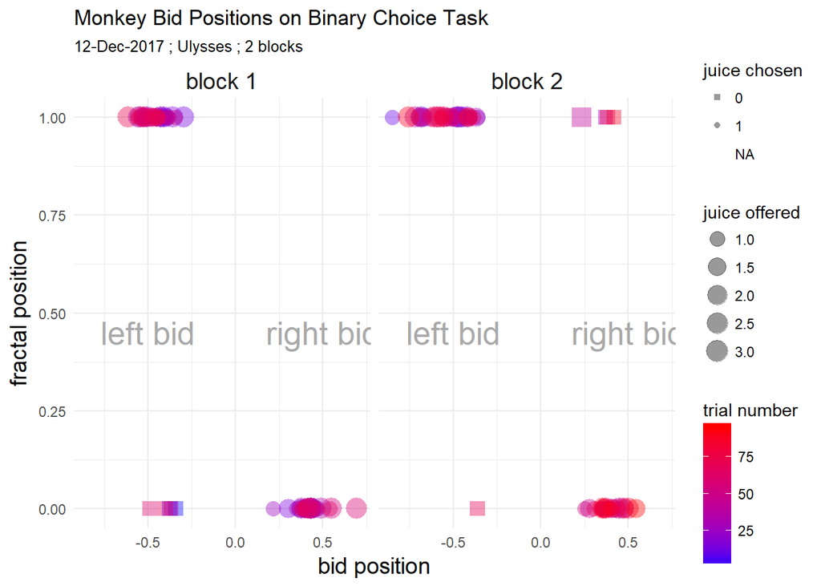

```r
#plot p1
p1
```

Graph of choices for each block. Circles indicate bid selectin the bundle, squares are bid selecting the budget. A fractal bid position of 1 means that the bundle is on the left hand side of the screen. Bids range from -1 (all the way to the left) to 1 (all the way to the right)

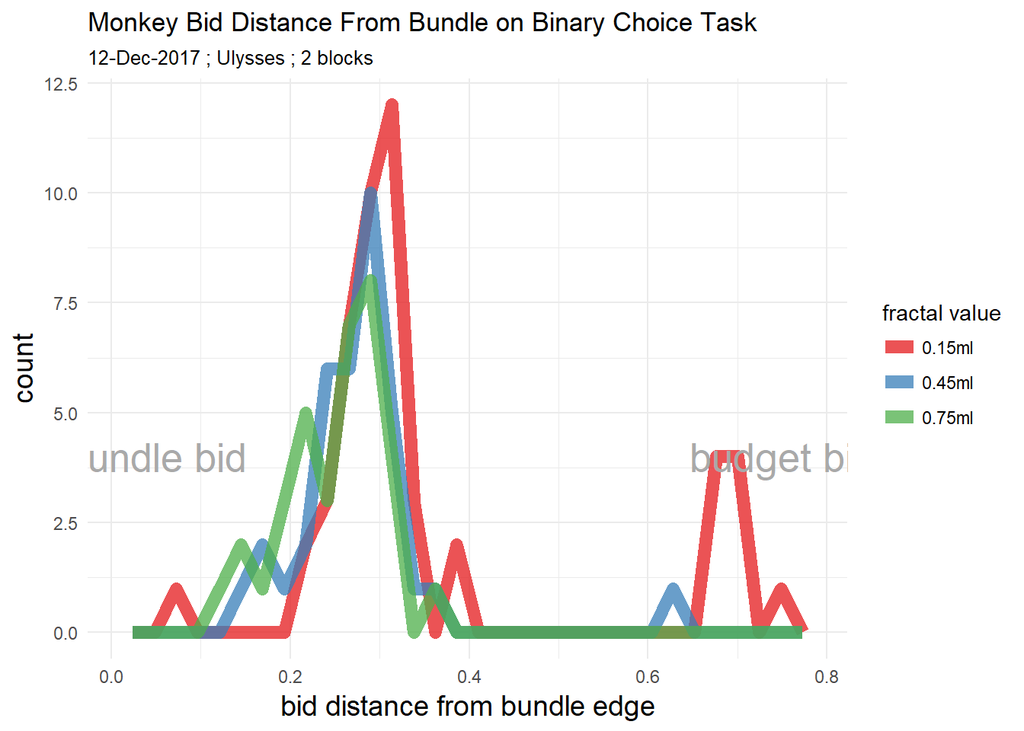

```r
#plot p2
p2
```

Graph showing all choices and how far away they are from the edge of the screen on the bundle side. 0 indicates full movement to the bundle side of the screen and 1 represent full movement away. Count is over all blocks for all values of the fractal (in ml of juice).

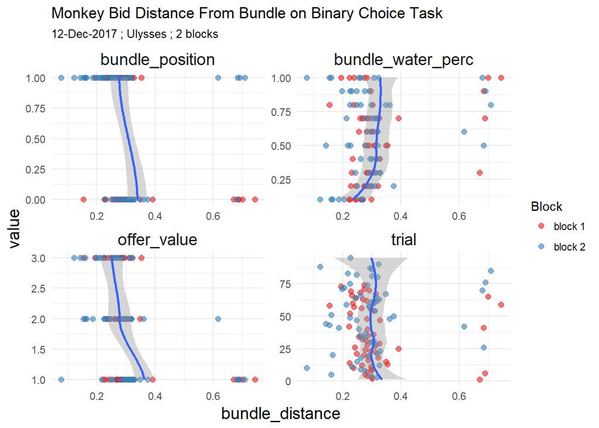

```r
#plot p3
p3
```

Graphs of various factors against the distance from the bundle side of the screen the monkey bids.

Fit lines use LOESS method.

```r
#generate a model of likelihood to bid for th efractal dependent on it's position, value and associated water
model <- glm(data = task_data, fractal_bid~bundle_position + bundle_water_perc + offer_value + trial, family = "binomial")

#summarise the parameters
summary(model)
```

```
##
## Call:
## glm(formula = fractal_bid ~ bundle_position + bundle_water_perc +
##     offer_value + trial, family = "binomial", data = task_data)
##
## Deviance Residuals:
##      Min        1Q    Median        3Q       Max
## -2.99060   0.05259   0.16451   0.34631   1.11056
##
## Coefficients:
##                    Estimate Std. Error z value Pr(>|z|)
## (Intercept)        1.545431   1.652956   0.935  0.34981
## bundle_position    0.708927   0.793862   0.893  0.37185
## bundle_water_perc -4.346973   1.621863  -2.680  0.00736 **
## offer_value        2.490660   0.999182   2.493  0.01268 *
## trial             -0.003979   0.016008  -0.249  0.80369
## ---
## Signif. codes:  0 '***' 0.001 '**' 0.01 '*' 0.05 '.' 0.1 ' ' 1
##
## (Dispersion parameter for binomial family taken to be 1)
##
##     Null deviance: 68.841  on 119  degrees of freedom
## Residual deviance: 45.690  on 115  degrees of freedom
##   (49 observations deleted due to missingness)
## AIC: 55.69
##
## Number of Fisher Scoring iterations: 7
```